# Grouping and summarizing in R

Author

Bio724D: Fall 2024

Published

September 17, 2024

**Libraries**

```r
library(tidyverse)
library(palmerpenguins)
set.seed(20240916)
```

# Data

**Data set: Yeast colony morphology**

### Reference

Granek, J. A., D. Murray, Ö. Kayıkçı, and P. M. Magwene. 2013. The genetic architecture of biofilm formation in a clinical isolate of *Saccharomyces cerevisiae*. Genetics 193(2):587-600.[https://doi.org/10.1534/genetics.112.142067](https://academic.oup.com/genetics/article/193/2/587/6065366)

### Data availability on Dryad

[Dryad link: https://doi.org/10.5061/dryad.mn71g](https://doi.org/10.5061/dryad.mn71g)

### Brief description

- 70 offspring from a genetic cross used to carry out QTL mapping
- Genotype information at two major QTLs [grouping variable]
- Organismal and molecular phenotypes such as colony complexity score, gene expression, concentration of cyclic AMP [discrete and continuous traits]
- See `README_for_seg_strain_table.csv` on [Dryad](https://datadryad.org/stash/dataset/doi:10.5061/dryad.mn71g) for explanation of columns

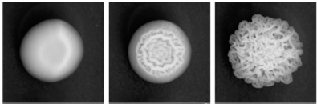

Yeast colonies

**Loading the yeast data**

Yeast colony morphology data from Granek et al. 2013:

```r
data_URL <- "https://tinyurl.com/36h67mhm"
yeast <- read_csv(data_URL)

glimpse(yeast)  # a prettier version of str
```

```
Rows: 70
Columns: 14
$ Strain     <chr> "PMY1235", "PMY1236", "PMY1237", "PMY1238", "PMY1239", "PMY…
$ Segregant  <chr> "s1", "s2", "s3", "s4", "s5", "s6", "s7", "s8", "s9", "s10"…
$ Pool       <chr> "S", "S", "S", "S", "S", "S", "S", "S", "S", "S", "S", "S",…
$ Cyr1.geno  <chr> "S", "S", "S", "S", "S", "S", "S", "S", "S", "S", "S", "S",…
$ Flo11.geno <chr> "S", "S", "S", "S", "S", "C", "S", "S", "S", "S", "S", "S",…
$ CM.a       <dbl> 1.0, 1.0, 1.0, 1.0, 1.0, 1.0, 1.0, 1.1, 1.0, 1.0, 1.0, 1.0,…
$ CM.b       <dbl> 1.0, 1.0, 1.0, 1.0, 1.0, 1.0, 1.1, 1.0, 1.0, 1.0, 1.0, 1.0,…
$ CM.c       <dbl> 1, 1, 1, 1, 1, 1, 1, 1, 1, 1, 1, 1, 1, 1, 1, 1, 1, 1, 1, 1,…
$ cAMP       <dbl> 194.38, 238.86, 245.32, 222.58, 168.99, 266.80, 194.64, 302…
$ Cyr1.expr  <dbl> 1438, 1410, 1292, 1814, 1204, 2274, 1334, 1374, 1722, 1674,…
$ Flo11.expr <dbl> 2035, 696, 143961, 10077, 11281, 11729, 112014, 160390, 350…
$ Adhes.a    <dbl> 0.0987, 0.0903, 0.0870, 0.0470, 0.1522, 0.1004, 0.0707, 0.0…
$ Adhes.b    <dbl> 0.1035, 0.1352, 0.2564, 0.1497, 0.1735, 0.1964, 0.1941, 0.1…
$ Adhes.c    <dbl> 0.1087, 0.1022, 0.2591, 0.1119, 0.1511, 0.1740, 0.2002, 0.1…
```

```r
# View(yeast)   # look at the data frame in the RStudio viewer
```

# Grouping

**Grouping using `group_by`**

The function `group_by` “decorates” a data frame with grouping information that you specify

- `group_by` by itself doesn’t do any further calculations
- Multiple variables can be used in a grouping statement

```r
yeast_grouped <-
  yeast |>
  group_by(Pool)

# use glimpse or str to view the grouped df
```

In this second example, we group by both morphology and genotype:

```r
yeast_grouped2 <-
  yeast |>
  group_by(Pool, Cyr1.geno)

# as before, use glimpse to take a look at this df
```

**Functions for exploring grouped data frames**

Although a grouped data frame doesn’t look different, its has additional information attached to it that affect how it works with group-aware operations. There are a variety of dplyr functions for querying a data frame about it’s grouping structure (if any):

You can check if a data frame is grouped using `is.grouped_df`

```r
is.grouped_df(yeast_grouped)
```

```
[1] TRUE
```

`groups` returns the variable(s) the data frame is grouped on:

```r
groups(yeast_grouped)
```

```
[[1]]
Pool
```

```r
groups(yeast_grouped2)
```

```
[[1]]
Pool

[[2]]
Cyr1.geno
```

`group_keys` returns a data frame describing the groups:

```r
group_keys(yeast_grouped)
```

| Pool |
| --- |
| C |
| S |

```r
group_keys(yeast_grouped2)
```

| Pool | Cyr1.geno |
| --- | --- |
| C | C |
| C | H |
| C | S |
| S | S |

`group_size` returns the number of observations in each group:

```r
group_size(yeast_grouped)
```

```
[1] 35 35
```

```r
group_size(yeast_grouped2)
```

```
[1] 22  2 11 35
```

**★ Grouping: Your turn**

Use the help and code exploration to understand what the functions `group_rows`, `group_indices` and `group_split` do.

**Removing grouping information using `ungroup`**

Grouping can be removed using the `ungroup` function:

```r
yeast_ungrouped <- ungroup(yeast_grouped)

is.grouped_df(yeast_ungrouped)
```

```
[1] FALSE
```

# Counting and Summarizing

**Counting**

The function `dplyr::count` when applied to a grouped data frame will return a data frame giving the count of observations per group:

```r
count(yeast_grouped2)
```

| Pool | Cyr1.geno | n |
| --- | --- | --- |
| C | C | 22 |
| C | H | 2 |
| C | S | 11 |
| S | S | 35 |

If counting is all you want to do, then you don’t need to explicitly group before hand as the `count` function takes grouping variables as arguments:

```r
yeast |>
  count(Pool, Cyr1.geno)
```

| Pool | Cyr1.geno | n |
| --- | --- | --- |
| C | C | 22 |
| C | H | 2 |
| C | S | 11 |
| S | S | 35 |

**Summarizing**

The `summarize` function allows us to create group-wise data summaries. This is a very powerful tool for calculate summary statistics for marginal distributions.

```r
yeast_grouped2 |>
  summarize(nobs = n(),
            mean_Cyr1.exp = mean(Cyr1.expr, na.rm = TRUE),
            sd_Cyr1.exp = sd(Cyr1.expr, na.rm = TRUE))
```

| Pool | Cyr1.geno | nobs | mean_Cyr1.exp | sd_Cyr1.exp |
| --- | --- | --- | --- | --- |
| C | C | 22 | 2141.842 | 561.1035 |
| C | H | 2 | 3229.500 | 569.2210 |
| C | S | 11 | 2645.889 | 666.8946 |
| S | S | 35 | 1535.533 | 309.7198 |

**Row-wise summaries**

`summarize` works across rows, but sometimes you want to make calculations across columns. The `rowwise` function facilitates this:

```r
yeast |>
  rowwise() |>
  mutate(mean.Adhes = mean(c_across(starts_with("Adhes"))),
         mean.CM = mean(c_across(CM.a:CM.c)))
```

| Strain | Segregant | Pool | Cyr1.geno | Flo11.geno | CM.a | CM.b | CM.c | cAMP | Cyr1.expr | Flo11.expr | Adhes.a | Adhes.b | Adhes.c | mean.Adhes | mean.CM |
| --- | --- | --- | --- | --- | --- | --- | --- | --- | --- | --- | --- | --- | --- | --- | --- |
| PMY1235 | s1 | S | S | S | 1.0 | 1.0 | 1.0 | 194.38 | 1438 | 2035 | 0.0987 | 0.1035 | 0.1087 | 0.10363333 | 1.000000 |
| PMY1236 | s2 | S | S | S | 1.0 | 1.0 | 1.0 | 238.86 | 1410 | 696 | 0.0903 | 0.1352 | 0.1022 | 0.10923333 | 1.000000 |
| PMY1237 | s3 | S | S | S | 1.0 | 1.0 | 1.0 | 245.32 | 1292 | 143961 | 0.0870 | 0.2564 | 0.2591 | 0.20083333 | 1.000000 |
| PMY1238 | s4 | S | S | S | 1.0 | 1.0 | 1.0 | 222.58 | 1814 | 10077 | 0.0470 | 0.1497 | 0.1119 | 0.10286667 | 1.000000 |
| PMY1239 | s5 | S | S | S | 1.0 | 1.0 | 1.0 | 168.99 | 1204 | 11281 | 0.1522 | 0.1735 | 0.1511 | 0.15893333 | 1.000000 |
| PMY1240 | s6 | S | S | C | 1.0 | 1.0 | 1.0 | 266.80 | 2274 | 11729 | 0.1004 | 0.1964 | 0.1740 | 0.15693333 | 1.000000 |
| PMY1241 | s7 | S | S | S | 1.0 | 1.1 | 1.0 | 194.64 | 1334 | 112014 | 0.0707 | 0.1941 | 0.2002 | 0.15500000 | 1.033333 |
| PMY1242 | s8 | S | S | S | 1.1 | 1.0 | 1.0 | 302.43 | 1374 | 160390 | 0.0639 | 0.1530 | 0.1540 | 0.12363333 | 1.033333 |
| PMY1243 | s9 | S | S | S | 1.0 | 1.0 | 1.0 | 214.02 | 1722 | 35037 | 0.0516 | 0.1429 | 0.1543 | 0.11626667 | 1.000000 |
| PMY1244 | s10 | S | S | S | 1.0 | 1.0 | 1.0 | 188.81 | 1674 | 16110 | 0.0771 | 0.2006 | 0.2185 | 0.16540000 | 1.000000 |

[output cut: 60 more lines]

```r
# two different ways to select columns above
# Note that ranges can be fragile when data gets reordered
```

# More complex operations on groups

For the following examples, we’ll return to using the `penguins` data set. Remember to load the `palmerpenguins` data set first.

**`mutate` after `group_by`**

`mutate` is “group aware”, and will apply it’s calculations in a group-wise manner on a grouped data frame.

Compare the following:

- Ungrouped data frame

```r
penguins |>
  mutate(deviation = body_mass_g - mean(body_mass_g, na.rm = TRUE)) |>
  pull(deviation) |> # pull is similar to $
  head(5)
```

```
[1] -451.7544 -401.7544 -951.7544        NA -751.7544
```

- Grouped data frame

```r
penguins |>
  group_by(species) |>
  mutate(deviation = body_mass_g - mean(body_mass_g, na.rm = TRUE)) |>
  pull(deviation) |> # pull is similar to $
  head(5)
```

```
[1]   49.33775   99.33775 -450.66225         NA -250.66225
```

**Applying functions by group using `group_map` and `group_modify`**

Sometimes we want to do grouped operations that are relatively complex, such as fitting a linear regression to sub-groups within the data.

This is relatively easy to generate a plot such as this in ggplot.

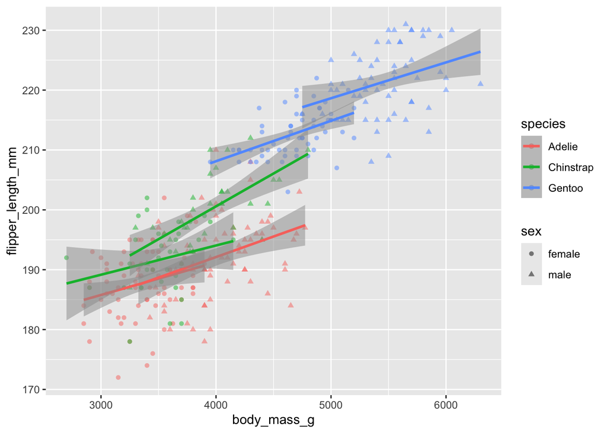

```r
penguins |>
  filter(!is.na(sex)) |>
  ggplot(aes(x = body_mass_g,
                     y = flipper_length_mm,
                     color = species,
                     shape = sex)) +
  geom_point(alpha = 0.5) +
  geom_smooth(method = lm, alpha=0.5)
```

ggplot is clearly fitting 6 different linear models to the grouped data (sex and species) “behind the scenes”. How could we do these calculations succinctly and efficiently ourselves? The function `group_map` and `group_modify` are useful to solve this problem.

```r
penguins_by_species_sex <-
  penguins |>
  filter(!is.na(sex)) |>
  group_by(species, sex)

lm_by_species_sex <-
  penguins_by_species_sex |>
  group_map(~lm(flipper_length_mm ~ body_mass_g, data = .x))

lm_by_species_sex
```

```
[[1]]

Call:
lm(formula = flipper_length_mm ~ body_mass_g, data = .x)

Coefficients:
(Intercept)  body_mass_g
  1.694e+02    5.461e-03


[[2]]

Call:
lm(formula = flipper_length_mm ~ body_mass_g, data = .x)

Coefficients:
(Intercept)  body_mass_g
  1.647e+02    6.859e-03


[[3]]

Call:
lm(formula = flipper_length_mm ~ body_mass_g, data = .x)

Coefficients:
(Intercept)  body_mass_g
  1.745e+02    4.883e-03


[[4]]

Call:
lm(formula = flipper_length_mm ~ body_mass_g, data = .x)

Coefficients:
(Intercept)  body_mass_g
  156.70889      0.01097


[[5]]

Call:
lm(formula = flipper_length_mm ~ body_mass_g, data = .x)

Coefficients:
(Intercept)  body_mass_g
  181.11845      0.00675


[[6]]

Call:
lm(formula = flipper_length_mm ~ body_mass_g, data = .x)

Coefficients:
(Intercept)  body_mass_g
  1.887e+02    5.987e-03
```

`group_modify` is similar to `group_map` but requires that the output of the function is a data frame. Since the `lm` function does not return it’s results in the form of a data frame, we turn to a package called [`broom`](https://broom.tidymodels.org/index.html) which is a library that turns model fit output into data frames for us. Broom has three basic functions: `tidy`, `glance`, and `augment`. Here we use the `tidy` function to report information about the coefficients of the linear models that are fit to each group in the data:

```r
library(broom)

lm_by_species_sex_df <-
  penguins_by_species_sex |>
  group_modify(~ broom::tidy(lm(flipper_length_mm ~ body_mass_g, data = .x)))

lm_by_species_sex_df
```

| species | sex | term | estimate | std.error | statistic | p.value |
| --- | --- | --- | --- | --- | --- | --- |
| Adelie | female | (Intercept) | 1.693971e+02 | 8.037057757 | 21.077006 | 2.814222e-32 |
| Adelie | female | body_mass_g | 5.461058e-03 | 0.002378221 | 2.296279 | 2.461450e-02 |
| Adelie | male | (Intercept) | 1.646785e+02 | 8.548387728 | 19.264275 | 6.530233e-30 |
| Adelie | male | body_mass_g | 6.858542e-03 | 0.002106481 | 3.255923 | 1.733787e-03 |
| Chinstrap | female | (Intercept) | 1.745111e+02 | 12.238637598 | 14.259029 | 2.049196e-15 |
| Chinstrap | female | body_mass_g | 4.883242e-03 | 0.003458816 | 1.411825 | 1.676522e-01 |
| Chinstrap | male | (Intercept) | 1.567089e+02 | 8.621887742 | 18.175705 | 2.000081e-18 |
| Chinstrap | male | body_mass_g | 1.096806e-02 | 0.002179945 | 5.031349 | 1.814086e-05 |
| Gentoo | female | (Intercept) | 1.811184e+02 | 7.571263771 | 23.921825 | 4.435406e-31 |
| Gentoo | female | body_mass_g | 6.750041e-03 | 0.001615010 | 4.179565 | 1.034644e-04 |

[output cut: 2 more lines]